# Task7

Tomas Kozlovskis

2016 m balandis 5 d

#### 1. The function tsdisplay(data, plot.type=“scatter”) is useful

#### for showing a time plot, ACF plot and lagged scatterplot on the

#### same graph. Use it to produce plots of the following time series:

#### bricksq, hsales, ibmclose

#### Can you spot the effects of seasonality, cyclicity and trend?

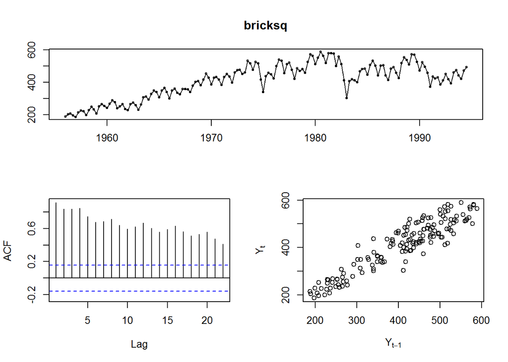

This data set seems to have seasonality.

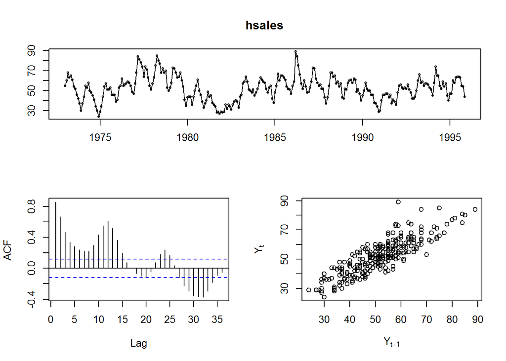

This data set has a seasonality as well.

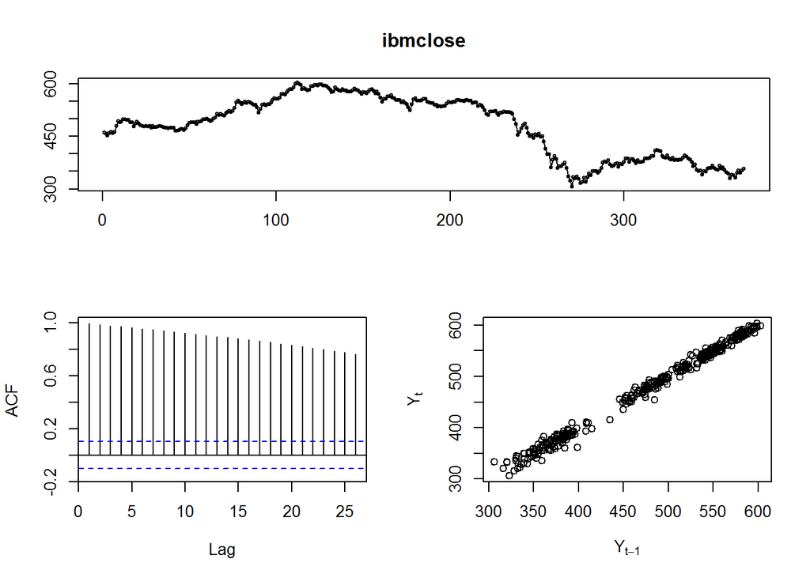

This data set seems to have a trend. Furthermore, variables are highly correlated.

### 3. For the data set bricksq:

#### (a) Split the data into two parts.

```r
bricks1 <- window(bricksq, end=1987.99)
bricks2 <- window(bricksq, start=1988)
```

#### (b) Check that your data have been split appropriately by producing

#### the following plot

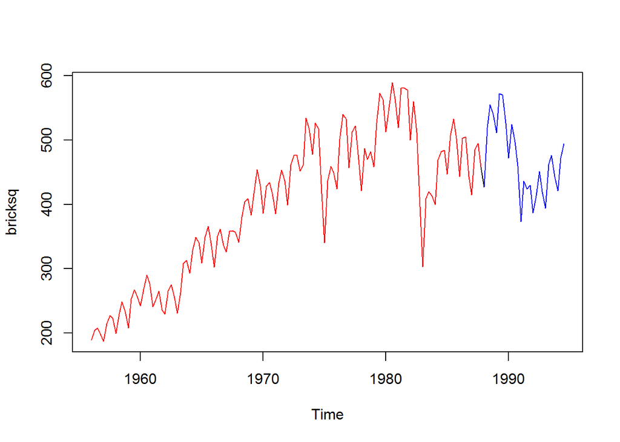

#### (c) Calculate forecasts using each of the four benchmark methods

#### applied to bricks1.

```r
fnaiv<-naive(bricks1, h=7)
fsnaiv<-snaive(bricks1, h=7)
fdrift<-rwf(bricks1, drift=T, h=7)
fmean<-meanf(bricks1, h=7)
```

#### (d) Compare the accuracy of your forecasts against the actual values

#### stored in bricks2.

```r
accnaiv
```

```
##                    ME     RMSE      MAE        MPE      MAPE      MASE
## Training set  2.11811 40.15629 31.85039  0.1878701  8.173353 0.9238477
## Test set     69.57143 83.66686 78.42857 12.4213912 14.495664 2.2748872
##                     ACF1 Theil's U
## Training set -0.07205841        NA
## Test set      0.12565160  1.589614
```

```r
accsnaiv
```

```
##                     ME     RMSE      MAE       MPE      MAPE     MASE
## Training set  8.508065 48.60531 34.47581  2.001127  8.666006 1.000000
## Test set     63.571429 69.56087 63.57143 11.764912 11.764912 1.843943
##                   ACF1 Theil's U
## Training set 0.7955186        NA
## Test set     0.5663318    1.3125
```

```r
accdrift
```

```
##                        ME     RMSE     MAE        MPE      MAPE      MASE
## Training set 2.237990e-14 40.10039 31.8393 -0.3959664  8.187045 0.9235258
## Test set     6.109899e+01 74.92563 70.5613 10.8607376 13.076737 2.0466905
##                     ACF1 Theil's U
## Training set -0.07205841        NA
## Test set      0.08379371  1.422113
```

```r
accmean
```

```
##                    ME     RMSE      MAE       MPE     MAPE     MASE
## Training set   0.0000 110.4965  95.0470 -9.952875 28.71184 2.756919
## Test set     131.5167 139.4870 131.5167 24.266553 24.26655 3.814755
##                   ACF1 Theil's U
## Training set 0.9195361        NA
## Test set     0.1256516  2.690181
```

#### (e) Which method does best? Why?

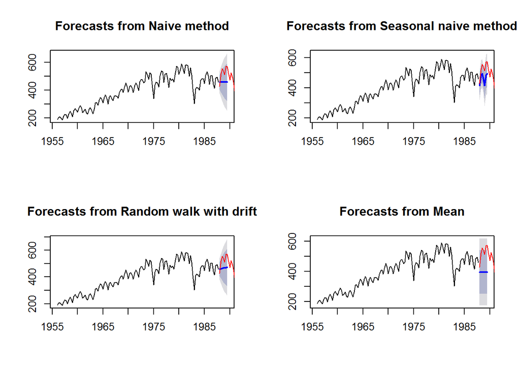

#### (f) For the best method, compute the residuals and plot them.

#### Do the residuals appear to be uncorrelated and normally distributed?

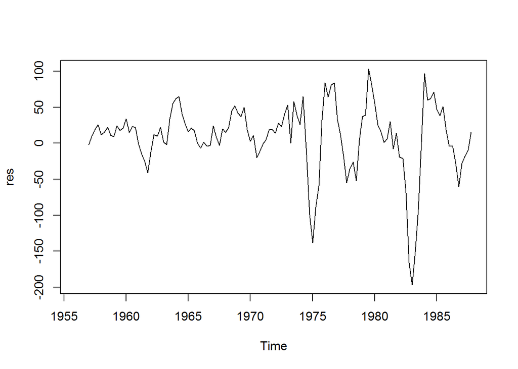

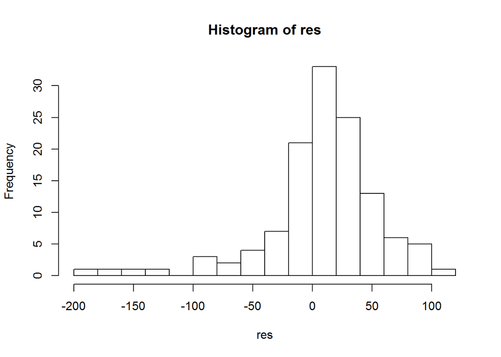

```r
hist(res, breaks="FD")
```

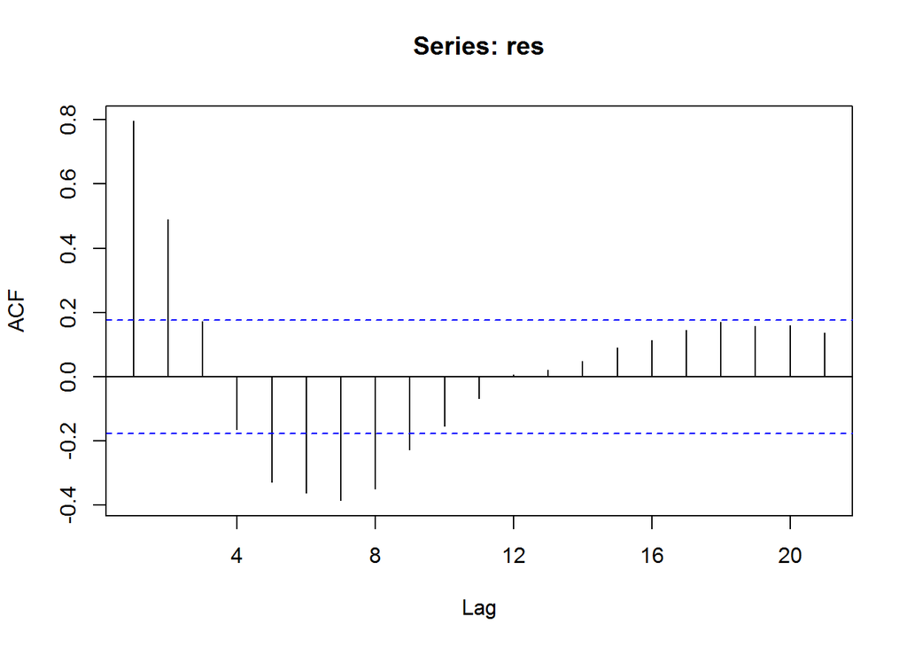

```r
Acf(res)
```

```r
shapiro.test(res)
```

```
##
##  Shapiro-Wilk normality test
##
## data:  res
## W = 0.8807, p-value = 1.514e-08
```

Unfortunately, residuals are not distributed normaly (they did not pass Shapiro-Wilk test for normality) and they are correlated.

#### (a) Produce some plots of the data in order to become familiar

#### with it.

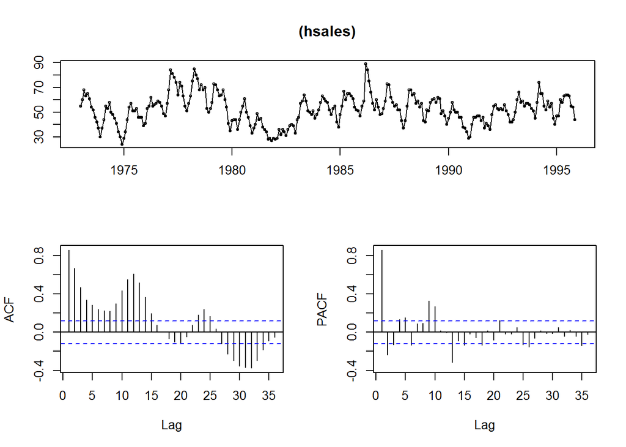

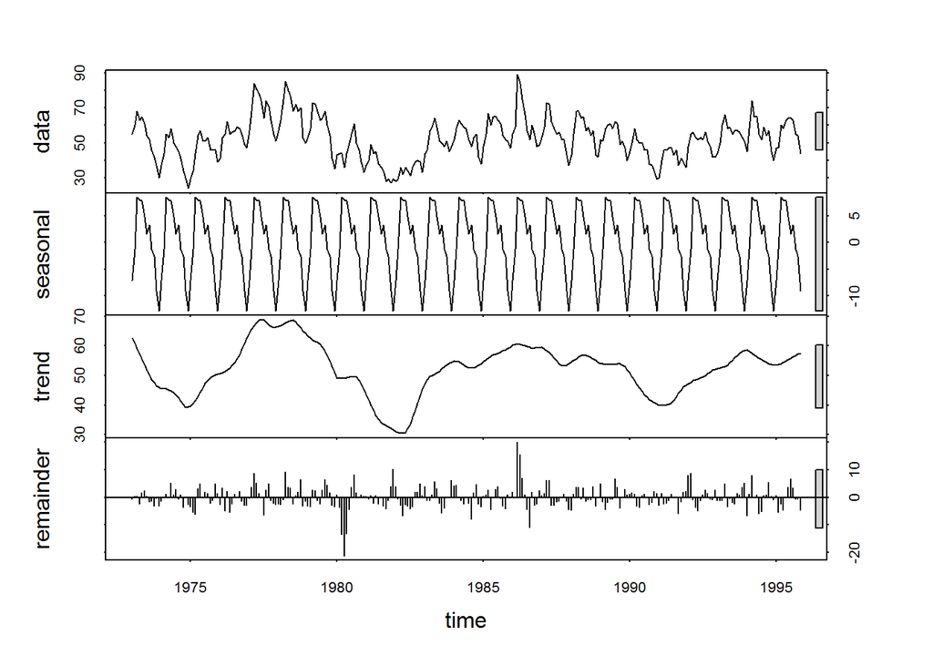

Looks like the data is seasonal and has no clear trend.

#### (b) Split the data into a training set and a test set, where the test

#### set is the last two years of data.

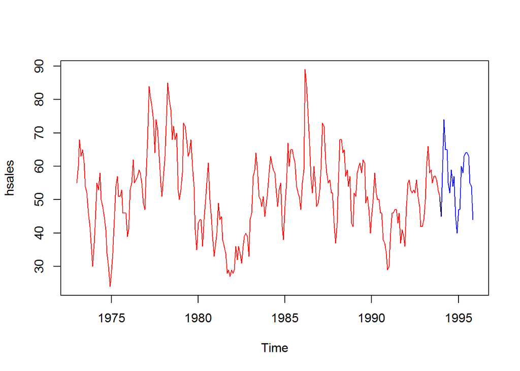

```r
sales1 <- window(hsales, end=1993.99)
sales2 <- window(hsales, start=1994)
plot(hsales)
lines(sales1,col="red")
lines(sales2,col="blue")
```

#### (c) Try various benchmark methods to forecast the training set and

#### compare the results on the test set. Which method did best?

```r
f.naiv<-naive(sales1, h=10)
f.snaiv<-snaive(sales1, h=10)
f.drift<-rwf(sales1, drift=T, h=10)
f.mean<-meanf(sales1, h=10)
```

```r
acc.naiv
```

```
##                       ME      RMSE      MAE        MPE      MAPE      MASE
## Training set -0.01593625  6.289813 4.988048 -0.7800232  9.880157 0.5876934
## Test set      7.40000000 10.639549 8.600000 11.1730634 13.839730 1.0132548
##                   ACF1 Theil's U
## Training set 0.1829708        NA
## Test set     0.2475017   1.15566
```

```r
acc.snaiv
```

```
##                  ME     RMSE    MAE       MPE      MAPE      MASE
## Training set 0.1375 10.57611 8.4875 -2.101638 17.633751 1.0000000
## Test set     2.2000  5.91608 4.4000  3.071172  7.098367 0.5184094
##                    ACF1 Theil's U
## Training set 0.83810799        NA
## Test set     0.06352785 0.7013126
```

```r
acc.drift
```

```
##                        ME      RMSE      MAE        MPE     MAPE     MASE
## Training set 2.377739e-15  6.289793 4.987730 -0.7474544  9.87819 0.587656
## Test set     7.487649e+00 10.697517 8.684462 11.3255912 13.98518 1.023206
##                   ACF1 Theil's U
## Training set 0.1829708        NA
## Test set     0.2448121  1.162563
```

```r
acc.mean
```

```
##                        ME     RMSE      MAE       MPE     MAPE     MASE
## Training set 2.480763e-15 12.13880 9.498898 -6.120182 20.30851 1.119163
## Test set     6.451587e+00 10.00315 7.841270  9.521209 12.60939 0.923861
##                   ACF1 Theil's U
## Training set 0.8661515        NA
## Test set     0.2475017  1.074061
```

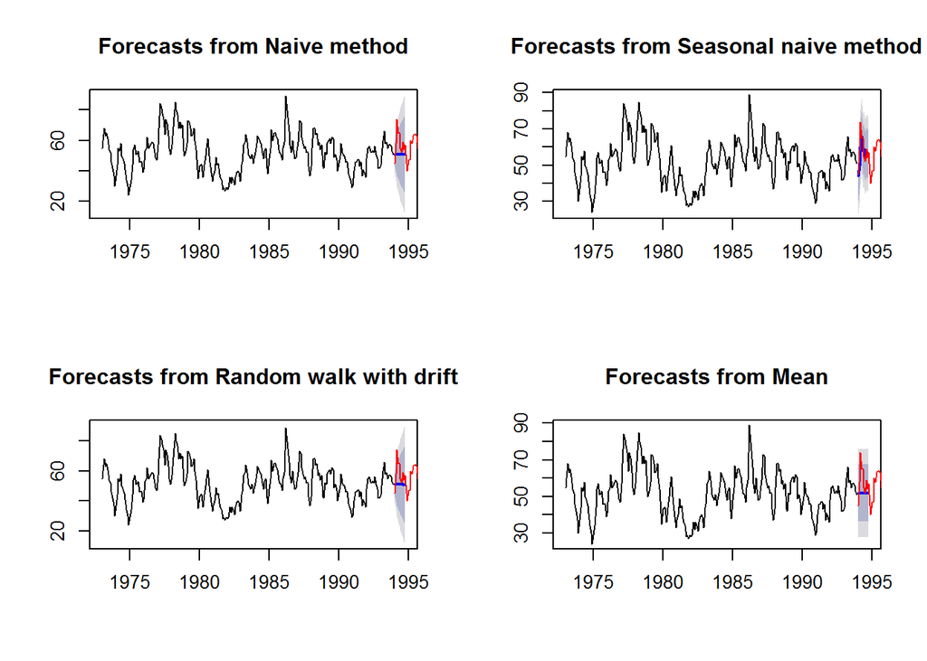

After taking a look at the graph, it seems that seasonal naive method would be best for forecasting. Test for accuracy proves it, because seasonal naive method’s accuracy criterias are the lowest of all of the tested methods.

#### (d) For the best method, compute the residuals and plot them.

#### What do the plots tell you?

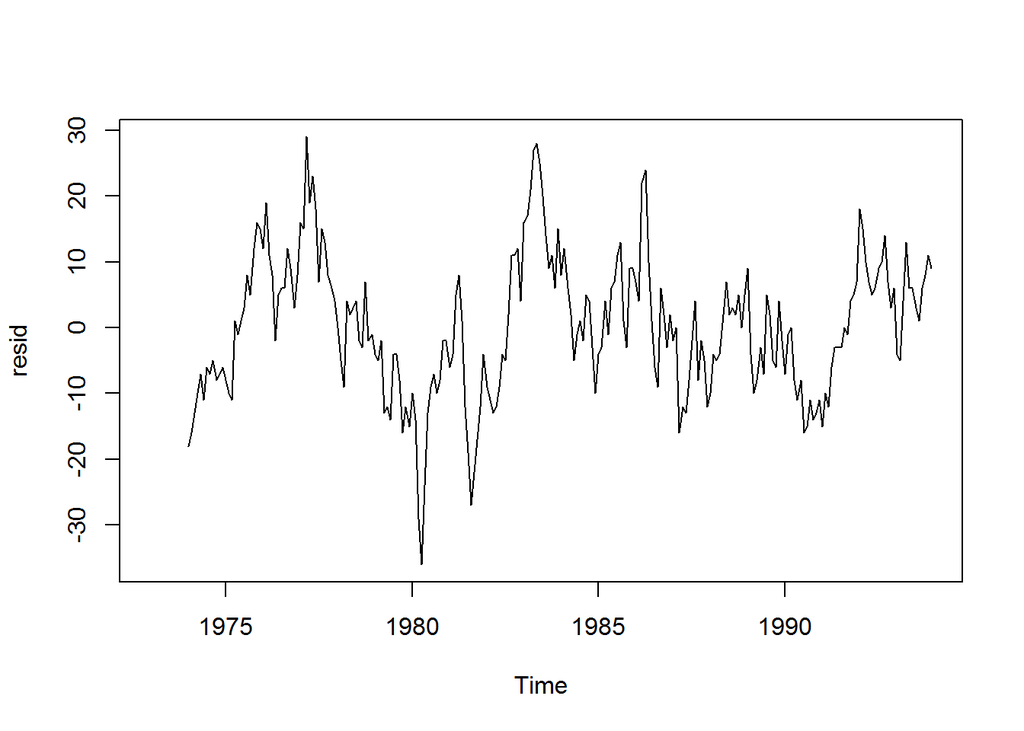

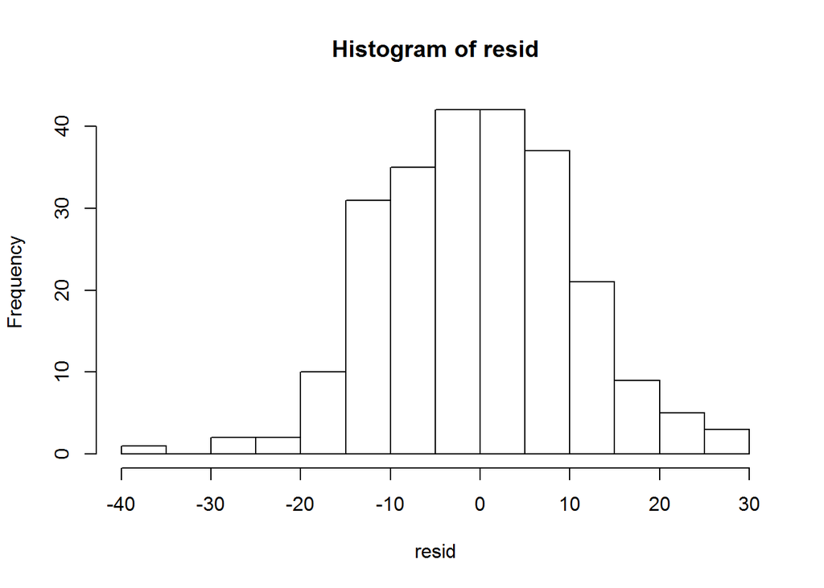

```r
hist(resid, breaks="FD")
```

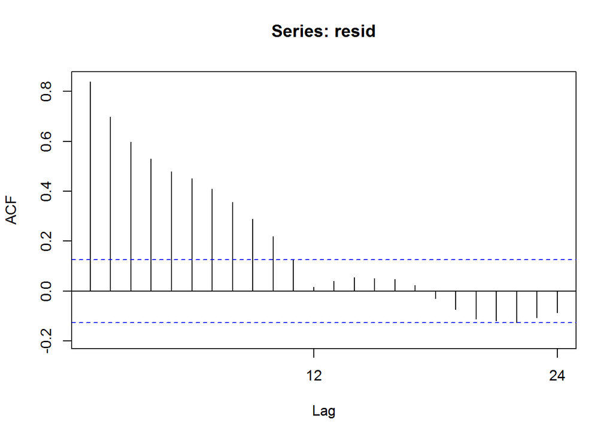

```r
Acf(resid)
```

```r
shapiro.test(resid)
```

```
##
##  Shapiro-Wilk normality test
##
## data:  resid
## W = 0.9933, p-value = 0.3581
```

#### (e) Can you invent a better forecasting method than any of the

#### benchmark methods for these data?

I tend think, that seasonal naive method forecasts well enough to trust him in order to make future decisions. However, it is only the case to this exact data.

I am well aware, that “data” can be treated as a plural noun, but according to $http://www.language-boutique.com/lost-in-translation-full-reader/these-data-are-or-this-data-is-.html$, data can be treated as both: singular and plural noun, so there is no mistake in writing “this data” or “these data”.